# Practical 1

Nina van Gerwen (1860852)

2022-11-17

```r
library(tidyverse)
library(glmnet)
```

## 2: Take home exercise

### 2.1: Gene expression data

#### Q1: Exploring the data

```r
gene_data <- read_rds("Data/gene_expressions.rds") %>% as.data.frame(.)
```

The data has a sample size of 237 observations (N) and it has information about 54676 variables (P). In other words P is much larger than N, which is indicative that the data is high-dimensional.

#### Q2: Creating histograms

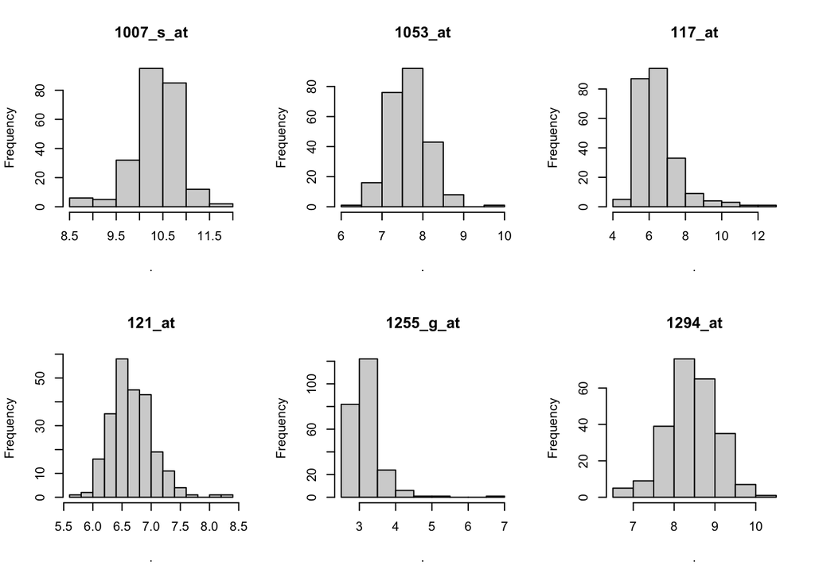

```r
par(mfrow = c(2, 3))

for(i in 2:7){
  gene_data[, i] %>%
    hist(., main = colnames(gene_data)[i])
}
```

#### Q3: Labeling the data

```r
final_data <- read_rds("Data/phenotypes.rds") %>%
  select(sample, disease) %>%
  full_join(x = ., y = gene_data, by = "sample")
```

#### Q4: Class imbalance

```r
final_data$disease %>%
  as.factor(.) %>%
  summary(.)
```

```
## normal  tumor
##    116    121
```

There is no class imbalance, as the two categories seem to be evenly balanced.

#### Q5: Splitting the data

```r
set.seed(1248)

final_data$split <- sample(c("train", "test"), size = nrow(final_data),
                           replace = TRUE, prob = c(0.8, 0.2))

train_data <- final_data %>% subset(split == "train", -split) %>%
  mutate(disease = as.factor(disease)) %>% as.data.frame(.)
test_data <- final_data %>% subset(split == "test", -split) %>%
  mutate(disease = as.factor(disease)) %>% as.data.frame(.)
```

## 3: Lab Exercises

### 3.1: Correlation filter & logistic regression

#### Q6: Highest correlated variables with disease

```r
library(ltm)
cors <- data.frame(var = colnames(train_data)[3:ncol(train_data)],
                   cor = NA)

k <- 1

for(i in 3:ncol(train_data)){
  cors[k, "cor"] <- biserial.cor(y = train_data$disease, x = as.numeric(train_data[, i]),
                                 use = "all.obs", level = 2)
  k <- k + 1
}

var_names <- cors %>%
  arrange(., desc(cor)) %>%
  head(., n = 10) %>%
  dplyr::select(var) %>%
  unlist(.)
```

#### Q7: Logistic regression with highest correlated variables

```r
fit_lr <- train_data[, c("disease", var_names)] %>%
  glm(disease ~ ., data = ., family = "binomial")
```

#### Q8: Evaluating performance through confusion matrix

```r
library(magrittr)
ifelse(predict(fit_lr, newdata = test_data, type = "response") > .5, 1, 0) %>%
  table(pred = ., true = test_data$disease)
```

```
##     true
## pred normal tumor
##    0     18     7
##    1      1    23
```

Accuracy is:
$$\frac{18+23}{18+23+1+7}
\approx .84$$

### 3.2: Regularized regression

#### Q9: Preparing data

```r
x_train <- train_data %>% dplyr::select(-disease, -sample)
y_train <- train_data$disease

x_test <- test_data %>% dplyr::select(-disease, -sample)
y_test <- test_data$disease
```

#### Q10: Fitting a LASSO regression

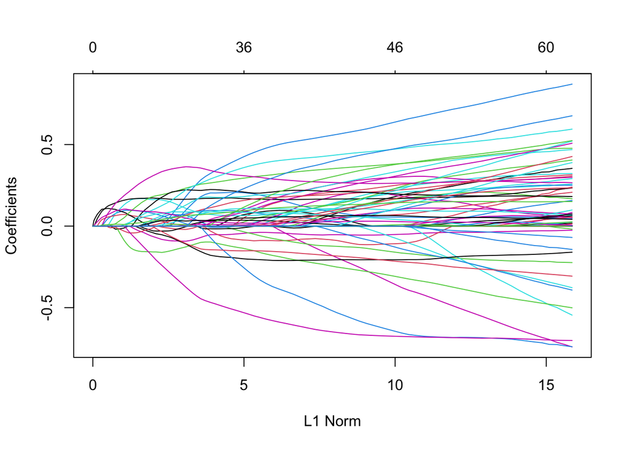

```r
fit_lasso <- glmnet(x = x_train, y = y_train, family = "binomial")

plot(fit_lasso)
```

At the left, you see complete shrinkage on the left (i.e., large $\lambda$). Above the plot you see how many variables are included. The more right you go (when there are more and more variables included and $\lambda$ decreases) you see that coefficients go further from 0.

#### Q11: Cross validated LASSO regression

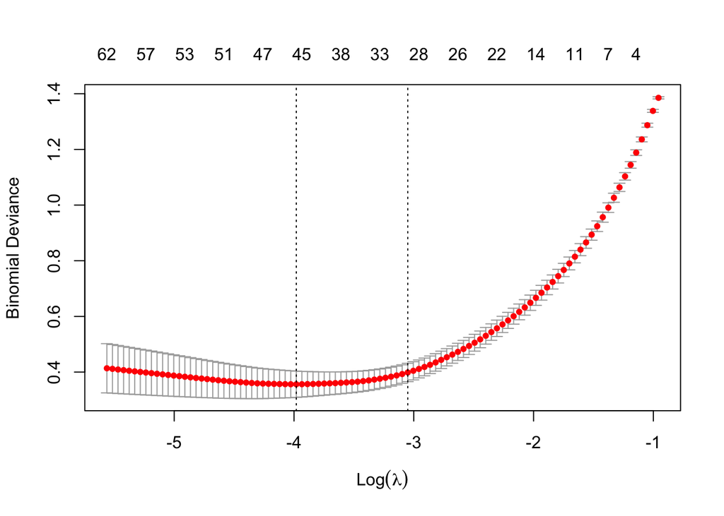

```r
cv_fit_lasso <- cv.glmnet(x = as.matrix(x_train), y = y_train, family = "binomial")

plot(cv_fit_lasso)
```

In this graph, you see that the error (i.e., binomial deviance) is smallest when the log of $\lambda$ is between -4 and -3 (which, for -4 equals that $\lambda = e^-4 =.018$).

#### Q12: Inspecting nonzero coefficients

```r
coefficients <- coef(cv_fit_lasso, s = "lambda.min")

which(coefficients[, 1] != 0) %>% names(.)
```

```
##  [1] "(Intercept)"  "1552411_at"   "1554952_s_at" "1555731_a_at" "1557228_at"
##  [6] "1558481_s_at" "1558489_at"   "1561555_at"   "1562348_at"   "1562681_at"
## [11] "1570503_at"   "203755_at"    "204735_at"    "205202_at"    "205756_s_at"
## [16] "206023_at"    "206054_at"    "206530_at"    "206858_s_at"  "208288_at"
## [21] "209284_s_at"  "209426_s_at"  "210334_x_at"  "212680_x_at"  "214961_at"
## [26] "215432_at"    "218487_at"    "218844_at"    "218888_s_at"  "218931_at"
## [31] "220233_at"    "220541_at"    "221929_at"    "226433_at"    "226633_at"
## [36] "228260_at"    "231534_at"    "232056_at"    "232572_at"    "232575_at"
## [41] "235342_at"    "236399_at"    "238463_at"    "239319_at"    "241462_at"
## [46] "242138_at"
```

```r
which(coefficients[, 1] != 0) %>% names(.) %in% var_names %>% sum(.)
```

```
## [1] 5
```

We find that there is overlap between the logistic regression model and the LASSO regression. In both models, 5 of the same variables were included. However, the LASSO regression obviously used many more other variables also.

#### Q13: Predicting values and evaluating performance

```r
table(pred = ifelse(predict(cv_fit_lasso, newx = as.matrix(x_test),
                            s = "lambda.min", type = "response") > .5, 1, 0),
      true = test_data$disease)
```

```
##     true
## pred normal tumor
##    0     18     8
##    1      1    22
```

Here, the accuracy is:
$$\frac{18+22}{18+22+8+1} \approx 0.82$$
. Accuracy is slightly lower compared to the logistic regression on the test data with a .5 cutoff on the probability. Both models are meh.